[figure not shown]

# Avatar: The Last Airbender Analysis

Avatar: The Last Airbender carved out its niche in storytelling with an intricate blend of fantasy and adventure. Upon its airing, it didn't take long for the series to capture the hearts of viewers, young and old. The tale of Aang's journey, burdened with the destiny of an Avatar, was set against a backdrop rich with mythology and cultures that felt as tangible as the elements its characters. This depth, coupled with a balanced mix of humor, heart, and heroism, propelled the series beyond its Saturday morning slot into a fixture of early-2000s pop culture.

As fans tuned in, captivated by episodes like "The Boy in the Iceberg" and "The Warriors of Kyoshi," their engagement was quantified through votes and ratings. Consistently high marks across the seasons reflect a quality of content that rarely wavered and often exceeded expectations. The figures offer a statistical echo of the acclaim the series has enjoyed, standing as a metric of its enduring appeal and the legacy of its story.

### Rating Distribution by Season

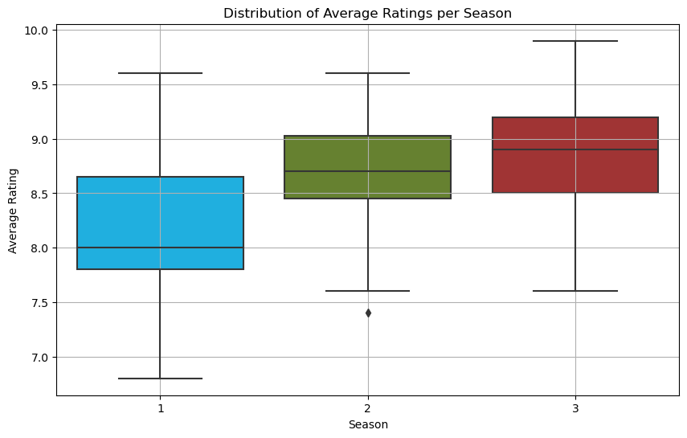

#### Season 1 (Water)

[output not shown]

#### Season 2 (Earth)

```
This season shows a higher median rating than Season 1, indicating a generally more favorable reception. The interquartile range (IQR) is tighter, which shows that the ratings are more consistent around the median, hovering above 8.5 but rarely going below 8.0.
```

#### Season 3 (Fire):

[output not shown]

Season 3 appears to be the most consistently highly-rated season, while Season 1 shows the most variability in ratings. The whiskers of the plots, which indicate the range of the ratings outside the middle 50% (excluding outliers), do not differ dramatically between seasons, suggesting that while there are episodes with lower ratings in each season, they are not extreme outliers.

[figure not shown]

### Most and Least Voted Episode

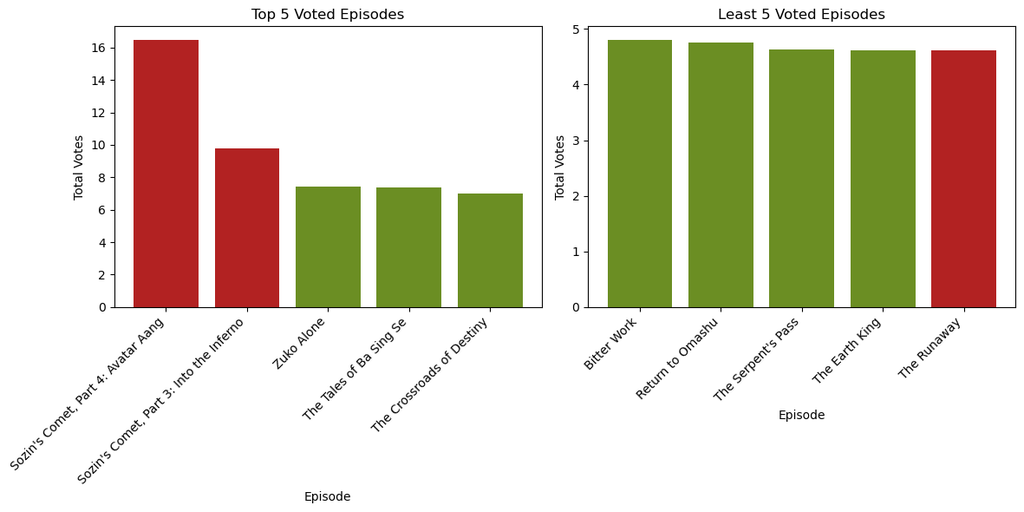

This graph tells a tale of audience engagement evolving over the show's lifespan. Season 3's pivotal episodes, marked in red, likely a mix of climax hype and the great farewell to a beloved series. In contrast, the episodes from Seasons 2, shown in green, have a steadier, though less pronounced, voting presence. This pattern speaks to a growing attachment with the series, as the emotional stakes ramped up and story arcs peaked, the fans' involvement deepened, culminating for the a passionate finale.

### Distribution of Rankings by Season

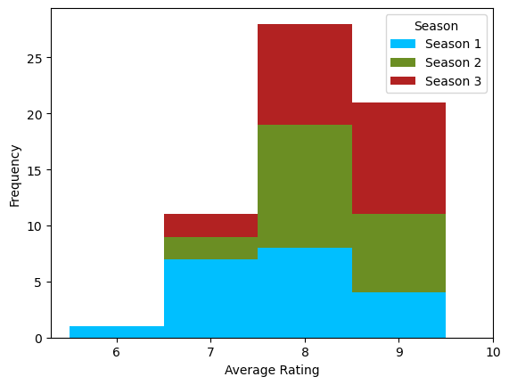

The stacked histogram illustrates the shifting audience ratings for "Avatar: The Last Airbender" across its three seasons. It's clear from the bands of color—blue for Season 1, green for Season 2, and red for Season 3—that as the series progressed, the frequency of higher ratings increased. Season 1 laid the groundwork with a solid base of ratings in the 7 to 8 range. Season 2 built on this foundation, pushing more into the 8 to 9 territory, suggesting a deepening viewer investment in the series. By Season 3, the ratings frequently touched the 9 to 10 mark, indicating peak viewer satisfaction and a strong series finale. Each color not only represents a chapter in Aang's story but also a step up in the series' narrative arc, with the increasing height of each color band mirroring the ascending quality and emotional stakes of the show.

### Episode Ratings Over Time by Season

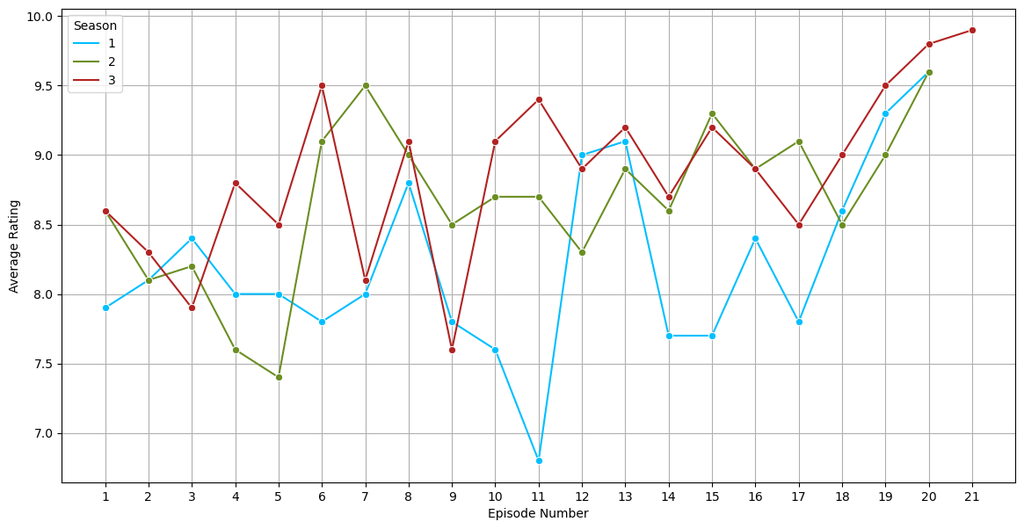

When we turn to the season finales, the graph shows a striking trend: each season's culmination is met with resounding approval, evidenced by significant peaks in ratings. These finales, marked by pivotal plot resolutions and climactic events, seem to have delivered exactly what the audience craved. Particularly for Season 3, we witness not just high ratings for the finale but a steady, ascending line leading up to it, indicating a consistent build-up of viewer satisfaction and engagement. This upward trajectory suggests a series successfully raising the stakes and deepening its narrative impact, culminating in a finale that stands as a high point of the series, reflected in its peak ratings.

Source: https://www.ratingraph.com/tv-shows/avatar-the-last-airbender-ratings-19148/